# ESM 204: Homework 2

Simulating a Carbon Market

Anthony Luna, Kazia Mermel, & Keene Morrow

4/27/2020

# Saving to Git

1. Save your shit
2. Go to the Git tab
3. Click the little white boxes next to the stuff you want to send to the other person
4. Click Commit
5. Write a witty but descriptive commit message
6. Hit Commit!
7. *PUUUUUUULLLLLLL* then push (I enjoy how much this sounds like instructions for a dance move)
8. Profit

To comply with the Paris Accord, governments around the world are seeking ways to reduce carbon emissions. You have been asked to provide guidance on how country “X” can most efficiently reduce carbon emissions. In this homework you will conduct data analysis, simulations, and policy analysis to help inform this decision. The data for this assignment are available in the file “HW2Data.csv”, available on Gauchospace. The data contain estimates of the marginal cost of carbon abatement for four economic sectors (sectors A, B, C, and D), for different levels of abatement. A few notes:

- Current carbon emissions in the sectors are: (A=170, B=200, C=230, and D=300).
- Sectors A, B, and C are in country X. Sector D is in a different country, Y.
- Prices are in $/ton and quantities are in tons.

Your task is to produce a *1 page memo*, with supporting appendices, to advise country X (and in some questions, country Y) about how best to reduce carbon emissions. Your memo and appendices must address the following questions. 1. Start with sector A. Plot that sector’s marginal abatement cost estimates and write down a plausible functional form for the marginal cost of abatement. Use regression analysis to estimate the parameters of that function. Repeating this for sectors B, C, and D will give you a model of the marginal cost of abatement function for each sector. How well do your models fit the data for each sector? You may need to experiment with different functional forms, and you don’t necessarily have to assume the same function for each sector. Produce a plot of the estimated marginal abatement cost functions in all four sectors (this plot should go in your memo).

# A

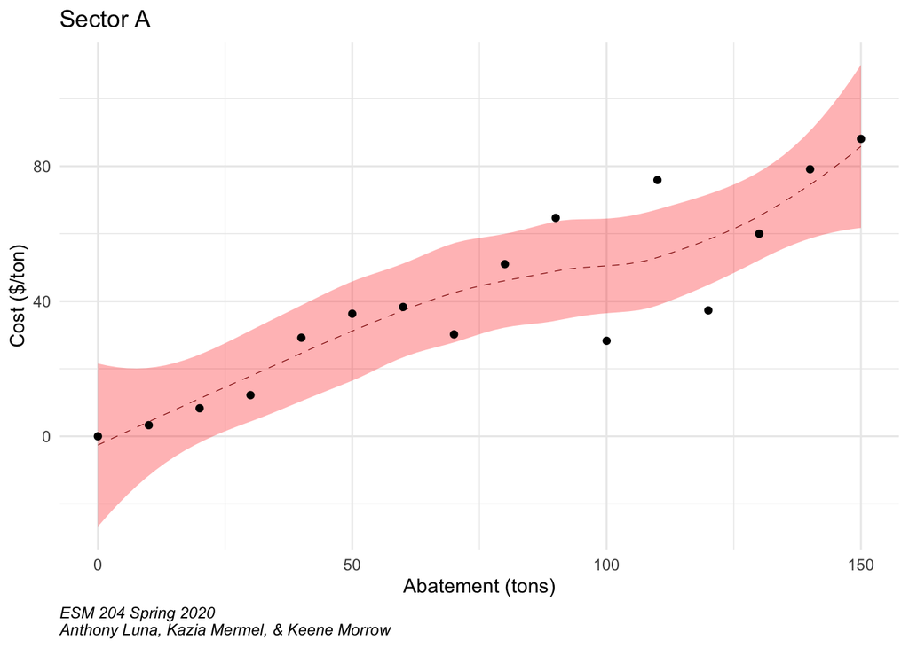

```r
# subset for just Sector A
carbon_a <- carbon_long %>%
  filter(sector == "A")

# Explore data
ggplot(data = carbon_a) +
  geom_smooth(aes(x = abatement,
                  y = mc),
              color = "dark red",
              size = 0.2,
              linetype = "dashed",
              fill = "red",
              alpha = 0.3) +
  geom_point(aes(x = abatement,
                 y = mc)) +
  labs(y = "Cost ($/ton)",
         x = "Abatement (tons)",
         title = "Sector A",
         # subtitle = "",
         caption = "ESM 204 Spring 2020\nAnthony Luna, Kazia Mermel, & Keene Morrow") +
    theme_minimal() +
    theme(plot.caption = element_text(hjust = 0, face = "italic"))
```

```r
# Model Exploration
## Linear
carbon_a_lm <- lm(mc ~ abatement, data = carbon_a)
summary(carbon_a_lm)
```

```
##
## Call:
## lm(formula = mc ~ abatement, data = carbon_a)
##
## Residuals:
##     Min      1Q  Median      3Q     Max
## -25.922  -5.482   1.978   8.470  17.808
##
## Coefficients:
##             Estimate Std. Error t value Pr(>|t|)
## (Intercept)  1.66250    6.26709   0.265    0.795
## abatement    0.51300    0.07119   7.206 4.52e-06 ***
## ---
## Signif. codes:  0 '***' 0.001 '**' 0.01 '*' 0.05 '.' 0.1 ' ' 1
##
## Residual standard error: 13.13 on 14 degrees of freedom
## Multiple R-squared:  0.7876, Adjusted R-squared:  0.7725
## F-statistic: 51.93 on 1 and 14 DF,  p-value: 4.522e-06
```

```r
carbon_a_lm$coefficients[1]
```

```
## (Intercept)
##      1.6625
```

```r
carbon_a_lm$coefficients[2]
```

```
## abatement
##     0.513
```

# B

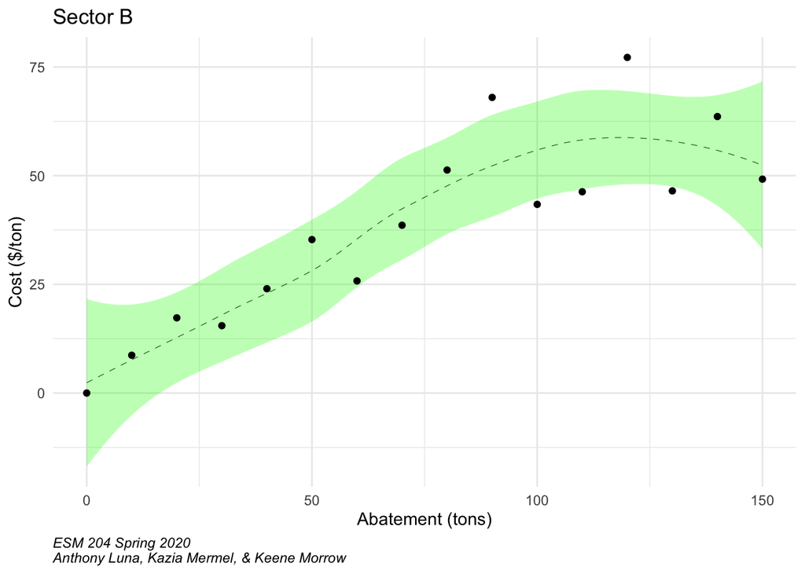

```r
# subset for just Sector B
carbon_b <- carbon_long %>%
  filter(sector == "B")

# Explore data
ggplot(data = carbon_b) +
  geom_smooth(aes(x = abatement,
                  y = mc),
              color = "dark green",
              size = 0.2,
              linetype = "dashed",
              fill = "green",
              alpha = 0.3) +
  geom_point(aes(x = abatement,
                 y = mc)) +
  labs(y = "Cost ($/ton)",
         x = "Abatement (tons)",
         title = "Sector B",
         # subtitle = "",
         caption = "ESM 204 Spring 2020\nAnthony Luna, Kazia Mermel, & Keene Morrow") +
    theme_minimal() +
    theme(plot.caption = element_text(hjust = 0, face = "italic"))
```

```r
# Model Exploration
## Linear
carbon_b_lm <- lm(mc ~ abatement, data = carbon_b)
carbon_b_lm
```

```
##
## Call:
## lm(formula = mc ~ abatement, data = carbon_b)
##
## Coefficients:
## (Intercept)    abatement
##      8.7853       0.3918
```

```r
## Non-Linear

# estimate growth rate (r) to be = carbon_b_lm$coefficients[2] ~ 0.39
# estimate K to be 60
# A = (K - P) / P = 10

carbon_b_nls <- nls(mc ~ K/(1 + A*exp(-r*abatement)),
             data = carbon_b,
             start = list(K = 58,
                          A = 10,
                          r = carbon_b_lm$coefficients[2]),
             trace = TRUE)
```

```
## 9235.207 :  58.0000000 10.0000000  0.3917794
## 2667.335 :  43.20679341 15.68236472  0.09017213
## 2182.579 :  46.01965473  8.60023529  0.06659541
## 1677.104 :  51.31033591  7.10061083  0.04632478
## 1367.481 :  58.26056271  9.83179695  0.04747591
## 1366.279 :  58.13907726 10.56861928  0.04863226
## 1366.248 :  58.19770304 10.54358319  0.04843611
## 1366.247 :  58.18285290 10.56987159  0.04850493
## 1366.247 :  58.18729290 10.56328744  0.04848638
## 1366.247 :  58.18607796 10.56515122  0.04849155
## 1366.247 :  58.18641564 10.56463661  0.04849012
```

```r
summary(carbon_b_nls)
```

```
##
## Formula: mc ~ K/(1 + A * exp(-r * abatement))
##
## Parameters:
##   Estimate Std. Error t value Pr(>|t|)
## K 58.18642    5.59273  10.404 1.13e-07 ***
## A 10.56464    8.25176   1.280   0.2228
## r  0.04849    0.01749   2.773   0.0158 *
## ---
## Signif. codes:  0 '***' 0.001 '**' 0.01 '*' 0.05 '.' 0.1 ' ' 1
##
## Residual standard error: 10.25 on 13 degrees of freedom
##
## Number of iterations to convergence: 10
## Achieved convergence tolerance: 6.469e-06
```

```r
model_out <- broom::tidy(carbon_b_nls) # cleaner model output with broom
model_out
```

```
## # A tibble: 3 x 5
##   term  estimate std.error statistic     p.value
##   <chr>    <dbl>     <dbl>     <dbl>       <dbl>
## 1 K      58.2       5.59       10.4  0.000000113
## 2 A      10.6       8.25        1.28 0.223
## 3 r       0.0485    0.0175      2.77 0.0158
```

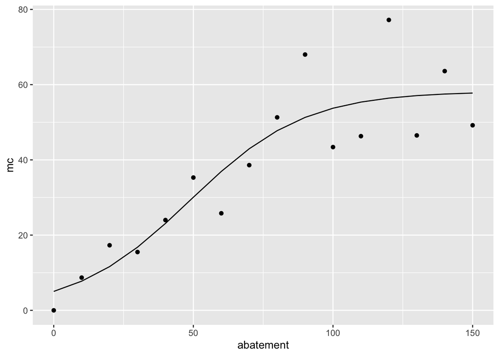

```r
## Predicted values using the model for plotting
predict_carbon_b_nls <- data.frame(mc_predict = predict(carbon_b_nls, carbon_b$abatement),
                                   sector = "B",
                                   abatement = carbon_b$abatement)

ggplot()+
  geom_point(data = carbon_b,
             aes(x = abatement,
                                 y = mc)) +
  geom_path(data = predict_carbon_b_nls,
            aes(x = abatement,
                y = mc_predict))
```

```r
#Here is some code Anthony Used for ecology assignment two. I've repurposed it for this assignment.
# Fit a linear model used for 'automatic good guess'
#fit.lm <- lm(mc~abatement , data = carbon_c)
#
## 'Automatic good guess' for use in model
#y0.ini <- fit.lm$coefficients[1]
#b.ini <- fit.lm$coefficients[2]
#x0.ini <- mean(carbon_b$abatement)
#
## Defining our linear with lower plateau function as described in Grassini et al. 2013
#linplat <-  function(x,y0,b,x0){ifelse(x<=x0, y0,y0+b*(x-x0))}
#
## nls model using the defined LLP and using starting values from our 'automatic good guess'
#LLP_carbon_c_model <-  nls(mc~linplat(abatement, y0, b, x0),
#             data = carbon_c,
#             start = list(y0=y0.ini,b=b.ini,x0=x0.ini),
#             trace=FALSE,
#             nls.control(maxiter=10000))
#
## Predicted values using the model for plotting
#predict_LLP_carbon_c <- data.frame(abatement_predict = predict(LLP_carbon_b_model,carbon_c),sector = "C",
#carbon_c$abatement)
```